# Projet

Marie-Anne Randrianarivony

2026-05-13

# Contexte

On cherche à prédire la demande énergétique donc il faudra faire un modèle de régression.

# Chargement des packages

```r
library(tidyverse)
library(lubridate)
library(httr2)
library(jsonlite)
library(janitor)
library(shiny)
library(glue)
library(ggplot2)
library(slider)

# Librairies utilisées pour la modélisation
library(xgboost)
library(vip)
library(tidyverse)
library(tidymodels)
library(glmnet)
```

```r
# Chargement des données de Hydro Québec sur les demandes d'électricité
df <- read.csv("C:/Users/Marie-Anne/OneDrive - Université du Québec à Chicoutimi/Documents/Prediction-de-la-demande-energetique-Hydro-Quebec-/data/historique-demande-electricite-quebec.csv")

head(df)
```

```
##                        date demande..MW.
## 1 2023-01-01T03:00:00-05:00     20010.46
## 2 2023-01-01T06:00:00-05:00     20411.55
## 3 2023-01-01T08:00:00-05:00     21561.22
## 4 2023-01-01T11:00:00-05:00     22842.33
## 5 2023-01-01T12:00:00-05:00     23224.36
## 6 2023-01-01T15:00:00-05:00     23045.90
```

```r
# Chargement des données météorologiques correspondant aux dates des demandes
df_meteo <-read.csv("C:/Users/Marie-Anne/OneDrive - Université du Québec à Chicoutimi/Documents/Prediction-de-la-demande-energetique-Hydro-Quebec-/data/open-meteo-45.52N73.61W226m.csv",
skip = 3 #pour sauter les 3 premières lignes d'informations
)

head(df_meteo)
```

```
##               time temperature_2m...C. rain..mm. snowfall..cm.
## 1 2019-01-01T00:00                -0.2       0.7          0.07
## 2 2019-01-01T01:00                 0.0       2.4          0.00
## 3 2019-01-01T02:00                -0.1       1.2          0.00
## 4 2019-01-01T03:00                -0.3       1.6          0.91
## 5 2019-01-01T04:00                -0.5       2.7          0.07
## 6 2019-01-01T05:00                -0.7       1.1          0.07
##   precipitation..mm. wind_speed_10m..km.h.
## 1                0.8                  17.7
## 2                2.4                  22.4
## 3                1.2                  16.7
## 4                2.9                  13.7
## 5                2.8                  14.2
## 6                1.2                  16.1
```

# 1. Nettoyage des données

## Conversion de la colonne date dans les 2 jeux de données au bon format

```r
df <- df %>%
  mutate(date=as.POSIXct(date, format="%Y-%m-%dT%H:%M", tz=Sys.timezone()))

head(df)
```

```
##                  date demande..MW.
## 1 2023-01-01 03:00:00     20010.46
## 2 2023-01-01 06:00:00     20411.55
## 3 2023-01-01 08:00:00     21561.22
## 4 2023-01-01 11:00:00     22842.33
## 5 2023-01-01 12:00:00     23224.36
## 6 2023-01-01 15:00:00     23045.90
```

```r
 df_meteo <- df_meteo %>%
  rename(date = time,
temperature = temperature_2m...C.,
pluie = rain..mm.,
neige = snowfall..cm.,
precipitation = precipitation..mm.,
vent = wind_speed_10m..km.h.
) %>%
  mutate(date = as.POSIXct(date,
                               format = "%Y-%m-%dT%H:%M",
                               tz = Sys.timezone())) %>%
  filter(!is.na(date)) # Suppression des observations sans date


head(df_meteo)
```

```
##                  date temperature pluie neige precipitation vent
## 1 2019-01-01 00:00:00        -0.2   0.7  0.07           0.8 17.7
## 2 2019-01-01 01:00:00         0.0   2.4  0.00           2.4 22.4
## 3 2019-01-01 02:00:00        -0.1   1.2  0.00           1.2 16.7
## 4 2019-01-01 03:00:00        -0.3   1.6  0.91           2.9 13.7
## 5 2019-01-01 04:00:00        -0.5   2.7  0.07           2.8 14.2
## 6 2019-01-01 05:00:00        -0.7   1.1  0.07           1.2 16.1
```

```r
df <- df %>%
  rename(demande_energetique = demande..MW.)
```

```r
print("Les colonnes dans le jeu de donnée des demandes énergétiques:")
```

```
## [1] "Les colonnes dans le jeu de donnée des demandes énergétiques:"
```

```r
colnames(df)
```

```
## [1] "date"                "demande_energetique"
```

```r
print("Les colonnes dans le jeu de données des informations météorologiques")
```

```
## [1] "Les colonnes dans le jeu de données des informations météorologiques"
```

```r
colnames(df_meteo)
```

```
## [1] "date"          "temperature"   "pluie"         "neige"
## [5] "precipitation" "vent"
```

## Fusion des jeux de données

```r
df_fusionne <- merge(df,df_meteo, by=c("date"))

head(df_fusionne)
```

```
##                  date demande_energetique temperature pluie neige precipitation
## 1 2019-01-01 01:00:00            23762.55         0.0   2.4  0.00           2.4
## 2 2019-01-01 02:00:00            23830.23        -0.1   1.2  0.00           1.2
## 3 2019-01-01 03:00:00            23608.07        -0.3   1.6  0.91           2.9
## 4 2019-01-01 04:00:00            23562.48        -0.5   2.7  0.07           2.8
## 5 2019-01-01 05:00:00            23546.16        -0.7   1.1  0.07           1.2
## 6 2019-01-01 06:00:00            23752.90        -0.9   1.6  0.14           1.8
##   vent
## 1 22.4
## 2 16.7
## 3 13.7
## 4 14.2
## 5 16.1
## 6 15.6
```

```r
nrow(df_fusionne)
```

```
## [1] 43824
```

```r
ncol(df_fusionne)
```

```
## [1] 7
```

## Gestion des valeurs manquantes

```r
sum(is.na(df_fusionne))
```

```
## [1] 45
```

On observe 45 données manquantes sur 43 824 observations.Étant donné que les valeurs manquantes ne sont pas trop importantes, on peut décider de les supprimer.

```r
df_fusionne <- df_fusionne %>%
  drop_na()
```

## Intervalles de dates

```r
date_debut <-format(min(df_fusionne$date, na.rm=TRUE), "%Y-%m-%d")
date_debut
```

```
## [1] "2019-01-01"
```

```r
date_fin <- format(max(df_fusionne$date, na.rm=TRUE), "%Y-%m-%d" )
date_fin
```

```
## [1] "2024-01-01"
```

## Gestion des valeurs aberrantes

Afin de gérer les valeurs aberrantes, l’utilisation de la méthode de la distance interquartile est idéal.

**Référence**: GitHub Documentation, https://essicolo.github.io/ecologie-mathematique-R/chapitre-outliers.html#valeurs-et-%C3%A9chantillons-aberrants-d%C3%A9finition-origines-m%C3%A9thodes-de-d%C3%A9tection-et-traitement

```r
# Définition de la fonction calculant la distance interquartile
iqr_01 <- function(x, probs = c(.25, .75), mult = 1.5, na.rm = TRUE) {

  io <- rep(NA, length(x)) # vecteur vide qui consignera si la valeur est aberrante ou non
  limits <- quantile(x, probs = probs, na.rm = na.rm)

  offset <- mult * (limits[2] - limits[1]) # calculer la distance limite des quartiles

  io[x > (limits[2] + offset) | x < (limits[1] - offset)] <- 0 # si en-deça ou au-delà des limites
  io[x <= (limits[2] + offset) & x >= (limits[1] - offset)] <- 1 # si à l'intérieur des limites
  return(io)
}
```

En utilisant la méthode de l’intervalle interquartile

```r
summary(df_fusionne$temperature)
```

```
##    Min. 1st Qu.  Median    Mean 3rd Qu.    Max.
##  -32.60   -2.40    7.00    6.45   16.50   33.50
```

```r
Q1 <- quantile(df_fusionne$temperature, 0.25, na.rm=TRUE)
Q3 <- quantile(df_fusionne$temperature, 0.75, na.rm=TRUE)
IQR <- Q3 - Q1

borne_inferieure <- Q1 - 1.5*IQR
borne_superieure <- Q3 - 1.5*IQR

cat("Borne inférieure:", borne_inferieure, "°C\n")
```

```
## Borne inférieure: -30.75 °C
```

```r
cat("Borne supérieure:", borne_superieure, "°C\n")
```

```
## Borne supérieure: -11.85 °C
```

```r
# Nombre de valeurs aberrantes
outliers_temp <- df_fusionne %>%
  filter(temperature < borne_inferieure | temperature > borne_superieure)

cat("Nombre de valeurs aberrantes:", nrow(outliers_temp), "\n")
```

```
## Nombre de valeurs aberrantes: 40650
```

# 2. Analyse exploratoire des données

## Séparation des variables temporelles en heure, jour, mois, année et weekend

```r
df_fusionne <- df_fusionne %>%
  mutate(
    heure = hour(date),
    jour = wday(date, label =TRUE, abbr = FALSE),
    mois = month(date, label =TRUE, abbr =FALSE),
    annee = year(date),
    weekend = wday(date) %in% c(1,7)
  )
```

## Distribution de la demande énergétique

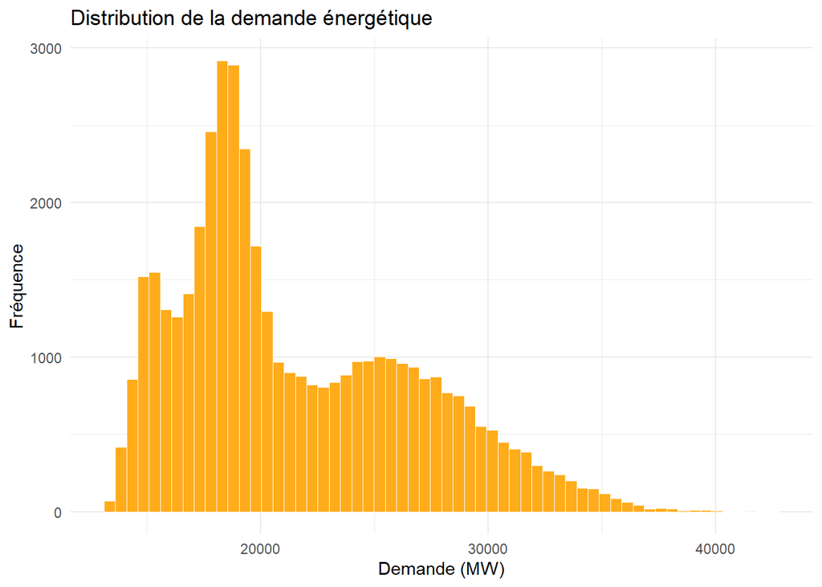

```r
ggplot(df_fusionne, aes(x=demande_energetique)) +
  geom_histogram(bins = 60, fill ="#FFAC1C", color="white", linewidth =0.2) +

  labs(title = "Distribution de la demande énergétique",
       x="Demande (MW)", y ="Fréquence") +
  theme_minimal()
```

On peut également observer qu’il y a des valeurs qui s’étendent autour des 30 000 MW.

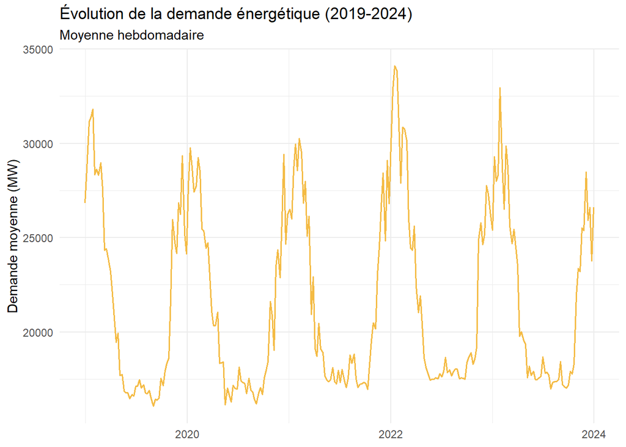

```r
df_fusionne %>%
  group_by(semaine = floor_date(date, "week")) %>%
  summarise(demande_moyenne = mean(demande_energetique, na.rm =TRUE)) %>%
  ggplot(aes(x =semaine, y = demande_moyenne)) +
  geom_line(color ="#F4BB44", linewidth = 0.7) +
  theme(plot.title = element_text(size = 10),
        plot.subtitle =element_text(size = 8)) +
  labs(title= "Évolution de la demande énergétique (2019-2024)",
       subtitle = "Moyenne hebdomadaire",
       x = NULL, y="Demande moyenne (MW)") +
theme_minimal()
```

On observe que chaque année, la consommation énergétique peut être dans les alentours de 30 000 MW. En 2022, la consommation énergétique a dépassé les 30 000 MW.

## Tendance mensuelle de la demande énergétique

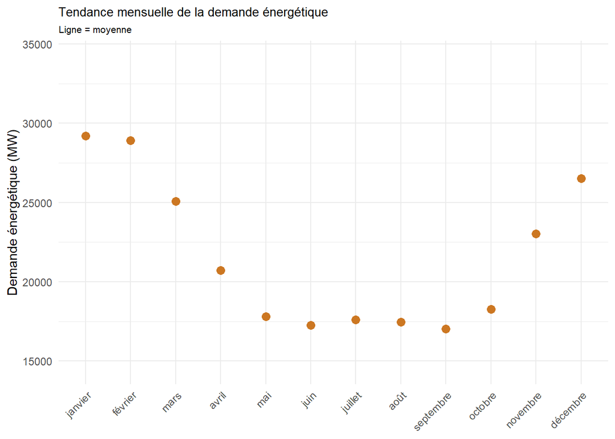

```r
df_fusionne %>%
  group_by(mois) %>%
  summarise(
    demande_moyenne = mean(demande_energetique, na.rm =TRUE),
    p10 = quantile(demande_energetique, 0.10, na.rm =TRUE),
    p90 = quantile(demande_energetique, 0.90, na.rm=TRUE)
  ) %>%
  ggplot(aes(x =mois, y =demande_moyenne, groupe = 1)) +
  geom_ribbon(aes(ymin = p10, ymax= p90), fill ="#F4BB44", alpha = 0.5) +
  geom_line(color = "#CC7722", linewidth=1.2) +
  geom_point(color = "#CC7722", size=3) +
  labs(title="Tendance mensuelle de la demande énergétique", subtitle = "Ligne = moyenne", x =NULL, y="Demande énergétique (MW)") +
  theme_minimal() +
  theme(axis.text.x = element_text(angle = 45, hjust =1),
        plot.title =element_text(size=10),
        plot.subtitle =element_text(size=8))
```

Cette tendance mensuelle se base sur toutes les années de 2019 jusqu’à 2024. On constate que pendant la saison hivernale, on a des hausses de demande énergétique autour de 30000 MW, plus exactement en Janvier et Février. Tandis que durant la saison estivale, les demandes sont en baisses aux alentours de 17 000 MW de Mai jusqu’en Août.

On constate que la température est une variable influencant les demandes énergétiques.

## Relation entre la demande et la température

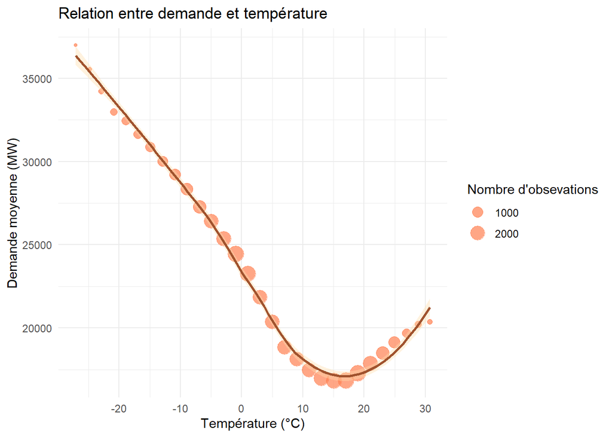

```r
df_fusionne %>%
  # regrouper les températures en intervalle de 2°C
  mutate(temp_bin = cut(temperature, breaks = seq(-30, 40, by=2))) %>%
  # calculer la demande moyenne par groupe crée ci-dessus
  group_by(temp_bin) %>%
  summarise(
    demande_moyenne = mean(demande_energetique, na.rm=TRUE),
    temp_moyenne = mean(temperature, na.rm=TRUE),
    n = n()
  ) %>%
  # Filtrage des groupes avec peu d'observations
  filter(n>20) %>%
  ggplot(aes(x = temp_moyenne, y = demande_moyenne)) +
  geom_point(aes(size=n), color="#FF7F50", alpha = 0.7) +
  geom_smooth(method="loess", se=TRUE, color="#A0522D", fill="#FFDEAD") +
  labs(title="Relation entre demande et température",
x="Température (°C)",
y="Demande moyenne (MW)",
size="Nombre d'obsevations") +
theme(plot.title =element_text(size=5)) +
  theme_minimal()
```

## Courbe montrant la tendance de la demande énergétique durant la semaine et par heure

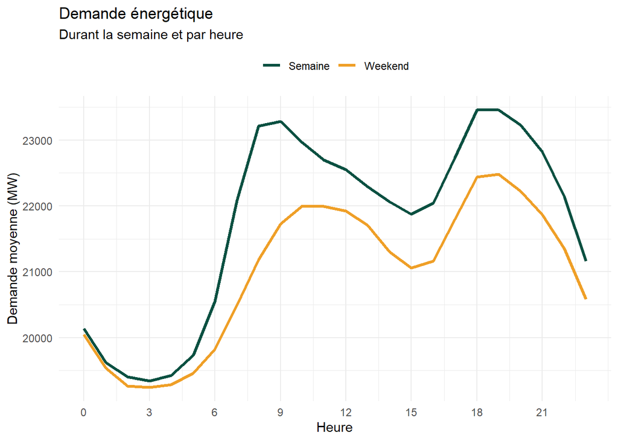

```r
df_fusionne %>%
  mutate(jour = ifelse(weekend, "Weekend", "Semaine")) %>%
  group_by(heure, jour) %>%
  summarise(demande_moyenne = mean(demande_energetique, na.rm=TRUE), .groups="drop") %>%
  ggplot(aes(x = heure, y = demande_moyenne, color =jour)) +
  geom_line(linewidth = 1.2) +
  scale_color_manual(values=c("Semaine" = "#085041", "Weekend"= "#EF9F27")) +
  scale_x_continuous(breaks = seq(0,23,3)) +
                       labs(title="Demande énergétique",
                            subtitle="Durant la semaine et par heure",
                            x="Heure",
                            y="Demande moyenne (MW)", color=NULL) +
                       theme_minimal() +
                       theme(legend.position ="top")
```

Les clients de Hydro Québec consomment plus d’énergie pendant les jours ouvrables et consomment moins la fin de semaine.

Pendant les jours ouvrables, on observe que les demandes énergétiques s’intensifient entre 7h et 10h ce qui peut réfleter le réveil et le début du travail. Elles s’intensifient également entre 18h et 19h ce qui correspondent aux heures de retours du travail.

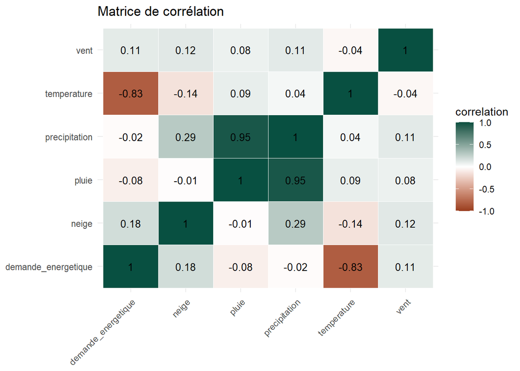

```r
df_fusionne %>%
  select(demande_energetique, temperature, pluie, neige, precipitation, vent) %>%
  cor(use ="pairwise.complete.obs") %>%
  as.data.frame() %>%
  rownames_to_column("var1") %>%
  pivot_longer(-var1, names_to="var2", values_to="correlation") %>%
  ggplot(aes(x=var1, y=var2, fill=correlation)) +
  geom_tile(color="white") +
  geom_text(aes(label=round(correlation, 2)) , size=3.5) +
  scale_fill_gradient2(low="#993C1D", mid="white", high="#085041", midpoint=0, limits=c(-1,1)) +
  labs(title="Matrice de corrélation", x=NULL, y=NULL) +
  theme_minimal() +
  theme(axis.text.x=element_text(angle=45, hjust=1))
```

On remarque également qu’il y a une corrélation entre la pluie et les précipitations. Garder les deux n’apporteront rien à l’analyse. On va seulement garder la variable pluie.

Le vent ne représente pas une influence directe sur la consommation électrique.

# Enrichissement des données

## Suppression de la variable “Précipitation”

```r
df_fusionne <- df_fusionne %>%
  select(-precipitation)
```

## Ajout des métriques standards à la prédiction de la demande énergétique

Afin de mieux capturer la consommation énergétique, nous allons mettre au point des métriques HDD et CDD. HDD mesure la demande de chauffage en fonction des jours où la température est inférieure à une valeur de référence. CDD représente la demande de climatisation lors des journées plus chaudes.

Référence: Leveraging HDD and CDD with Linear Regression for Enhancecd Energy Analysis in Python, https://www.linkedin.com/pulse/leveraging-hdd-cdd-linear-regression-enhanced-energy-analysis-kmetz-tzece/

Équations mathématiques:

où: $T_{base}$ est la température de référence pour les jours à haute température, en général 65°F(18°C). $T_{mean}$ est la moyenne des températures.

$CDD = T_{mean} - T_{base}$ si $T_{mean}$ est plus grand que $T_{base}$. $HDD = 0$, si $T_{mean}$ est plus petit que $T_{base}$.

où: $T_{base}$ est la température de référence pour les jours à basse température, en général 65°F(18°C). $T_{mean}$ est la moyenne des températures.

Référence: https://mrcc.purdue.edu/CLIMATE/Station/Daily/degreeday_description.html

```r
df_fusionne <- df_fusionne %>%
  mutate(
    hdd = pmax(0,18 - temperature),
    cdd = pmax(0, temperature - 18),

    # Lags de température
    temp_lag1 = lag(temperature, 1),
    temp_lag24 = lag(temperature, 24),

    # Moyenne mobiles de température
    temp_ma6h  = slide_dbl(temperature, mean, .before = 5,  .complete = TRUE),
    temp_ma24h = slide_dbl(temperature, mean, .before = 23, .complete = TRUE)
  )
```

## Encodage cyclique pour éviter le saut entre 23h et minuit

```r
df_fusionne <- df_fusionne %>%
  mutate(
    # Conversion en numérique
    mois_num = as.numeric(month(date)),
    jour_num = as.numeric(wday(date, week_start=1)),

    heure_sin     = sin(2 * pi * heure / 24),
    heure_cos     = cos(2 * pi * heure / 24),
    mois_sin      = sin(2 * pi * mois_num / 12),
    mois_cos      = cos(2 * pi * mois_num / 12),
    jour_sin      = sin(2 * pi * jour_num / 7),
    jour_cos      = cos(2 * pi * jour_num / 7)
  )
```

## Lags de température

Afin de permettre de considérer la température de l’heure précédente et d’hier à la même heure. La moyenne mobile permet de lisser les variations brusques au lieu de considérer qu’un seul pic de température sur une heure donnée.

```r
df_fusionne <- df_fusionne %>%
  mutate(
    temp_lag1 = lag(temperature, 1),
temp_lag24 = lag(temperature, 24),

# Moyenne mobiles de température
temp_ma6 = slide_dbl(temperature, mean, .before = 5, .complete = TRUE),
temp_ma24 = slide_dbl(temperature, mean, .before = 23, .complete =TRUE)
  )
```

## Lags de la demande énergétique

Ce lag sera servi en guise d’historique. Théoriquement, la demande d’aujourd’hui ressemblera au demande d’hier à la même heure et à la même heure de la semaine d’avant.

```r
df_fusionne <- df_fusionne %>%
  arrange(date) %>%
  mutate(
    demande_lag1 = lag(demande_energetique, 1),
    demande_lag24 = lag(demande_energetique, 24),
    demande_lag48 = lag(demande_energetique, 48),
    demande_lag168 = lag(demande_energetique, 168),

    # Moyenne mobile de la demande
    demande_ma24 = slide_dbl(demande_energetique, mean, .before=23, .complete=TRUE)
  )

# Suppression des lignes vides
df_fusionne <- df_fusionne %>%
  drop_na()
```

En regardant le jeu de donnée, la plupart des valeurs de CDD sont à 0. Les lignes de codes suivant permettent d’observer qu’il y a bel et bien des valeurs ayant un CDD supérieur à 0.

## Les valeurs ayant un CDD supérieur à 0

```r
df_fusionne %>%
  filter(cdd>0) %>%
  select(date, temperature, cdd) %>%
  head(10)
```

```
##                   date temperature cdd
## 1  2019-05-06 13:00:00        18.9 0.9
## 2  2019-05-06 14:00:00        19.7 1.7
## 3  2019-05-06 15:00:00        20.4 2.4
## 4  2019-05-06 16:00:00        20.3 2.3
## 5  2019-05-06 17:00:00        19.8 1.8
## 6  2019-05-06 18:00:00        18.9 0.9
## 7  2019-05-20 11:00:00        19.4 1.4
## 8  2019-05-20 12:00:00        20.5 2.5
## 9  2019-05-20 13:00:00        20.9 2.9
## 10 2019-05-20 14:00:00        20.9 2.9
```

# Modélisation

## Séparation du jeu d’entraînement et du jeu de test

```r
split_date <- df_fusionne %>%
  pull(date) %>%
  quantile(0.8) %>%
  as.POSIXct()

df_train <- df_fusionne %>%
  filter(date < split_date)
df_test <- df_fusionne %>%
  filter(date >= split_date)

cat("Train :", nrow(df_train), "observations, intervalles de dates: ",
    format(min(df_train$date), "%Y-%m-%d"), "jusqu'à",
    format(max(df_train$date), "%Y-%m-%d"), "\n")
```

```
## Train : 34888 observations, intervalles de dates:  2019-01-08 jusqu'à 2023-01-02
```

```r
cat("Test  :", nrow(df_test), "observations, intervalles de dates: ",
    format(min(df_test$date), "%Y-%m-%d"), "jusqu'à",
    format(max(df_test$date), "%Y-%m-%d"), "\n")
```

```
## Test  : 8723 observations, intervalles de dates:  2023-01-02 jusqu'à 2024-01-01
```

## Modèle Baseline

```r
df_test_baseline <- df_test %>%
  mutate(pred_baseline = demande_lag24) %>%
  filter(!is.na(pred_baseline))

mae_baseline  <- mean(abs(df_test_baseline$demande_energetique -
                            df_test_baseline$pred_baseline), na.rm = TRUE)
mape_baseline <- mean(abs((df_test_baseline$demande_energetique -
                             df_test_baseline$pred_baseline) /
                            df_test_baseline$demande_energetique)) * 100
ss_res <- sum((df_test_baseline$demande_energetique -
                 df_test_baseline$pred_baseline)^2, na.rm = TRUE)
ss_tot <- sum((df_test_baseline$demande_energetique -
                 mean(df_test_baseline$demande_energetique))^2, na.rm = TRUE)
r2_baseline <- 1 - ss_res / ss_tot

cat("Baseline (lag 24h)\n")
```

```
## Baseline (lag 24h)
```

```r
cat("MAE  :", round(mae_baseline, 2), "MW\n")
```

```
## MAE  : 1100.69 MW
```

```r
cat("MAPE :", round(mape_baseline, 2), "%\n")
```

```
## MAPE : 4.77 %
```

```r
cat("R²   :", round(r2_baseline, 4), "\n")
```

```
## R²   : 0.899
```

## Preprocessing du modèle

```r
recette <- recipe(demande_energetique~., data = df_train) %>%
  update_role(date, new_role="ID") %>%
  step_rm(mois, jour) %>%
  step_rm(demande_lag1) %>% # retirer le lag 1h
  # Convertir la variable Weekend en numérique
  step_mutate(weekend = as.integer(weekend)) %>%

  step_zv(all_predictors()) %>%
  step_normalize(all_numeric_predictors())
```

## Modèle XGBOOST

```r
spec_xgb <- boost_tree(
  trees = 500,
  tree_depth = tune(),
  min_n = tune(),
  learn_rate = tune()
) %>%
  set_engine("xgboost") %>%
  set_mode("regression")
```

### Workflow

```r
workflow_xgb <- workflow() %>%
  add_recipe(recette) %>%
  add_model(spec_xgb)
```

### Validation croisée temporelle

On va utiliser une validation croisée afin d’éviter une fuite de donnée temporelle. Afin de s’assurer que les données de validation soient des données que le modèle n’a jamais vue. Le modèle devrait alors performer sur toute une période et pas seulement sur une période donnée.

```r
cv_splits <- sliding_period(
  df_train,
  index = date,
  period = "week",
  lookback = 20,
  assess_stop = 2,
  step = 2
)
cat("Nombre de folds CV:", nrow(cv_splits))
```

```
## Nombre de folds CV: 94
```

### Grille de recherche

```r
set.seed(42)
grille <- grid_latin_hypercube(
  tree_depth(),
  min_n(),
  learn_rate(),
  size = 15
)
```

### Réduction du temps de chargement

```r
cv_splits_rapide <- sliding_period(
  df_train,
  index = date,
  period = "week",
  lookback = 20,
  assess_stop = 2,
  step = 4
)

cat("Nombre de folds:" , nrow(cv_splits_rapide), "\n")
```

```
## Nombre de folds: 47
```

```r
grille_rapide <- grid_latin_hypercube(
  tree_depth(),
  min_n(),
  learn_rate(),
  size = 8
)
```

```r
resultats_tuning <- tune_grid(
  workflow_xgb,
  resamples = cv_splits_rapide,
  grid = grille_rapide,
  metrics = metric_set(mae, rmse),
  control = control_grid(verbose = TRUE)
)
```

### Choix des meilleurs hyperparamètres

```r
best_params <- select_best(resultats_tuning, metric ="mae")
cat("Meilleurs hyperparamètres:")
```

```
## Meilleurs hyperparamètres:
```

```r
print(best_params)
```

```
## # A tibble: 1 × 4
##   min_n tree_depth learn_rate .config
##   <int>      <int>      <dbl> <chr>
## 1    14         13     0.0449 pre0_mod3_post0
```

### Entraînement sur le jeu de donnée d’entraînement

```r
workflow_final <- workflow_xgb %>%
  finalize_workflow(best_params)

fit_final <- workflow_final %>%
  fit(df_train)
```

### Évaluation sur le jeu de test

```r
predictions <- fit_final %>%
  augment(df_test)

mae_xgb  <- mean(abs(predictions$demande_energetique -
                       predictions$.pred), na.rm = TRUE)
mape_xgb <- mean(abs((predictions$demande_energetique -
                        predictions$.pred) /
                       predictions$demande_energetique)) * 100
ss_res_xgb <- sum((predictions$demande_energetique -
                     predictions$.pred)^2, na.rm = TRUE)
ss_tot_xgb <- sum((predictions$demande_energetique -
                     mean(predictions$demande_energetique))^2, na.rm = TRUE)
r2_xgb <- 1 - ss_res_xgb / ss_tot_xgb
```

## Modèle Régression Linéaire avec régularisation

```r
spec_glmnet <- linear_reg(
  penalty = tune(),

  mixture = tune()
) %>%
  set_engine("glmnet") %>%
  set_mode("regression")
```

**Penalty** permet de **pénaliser le modèle** si les coefficients sont trop grand.

**Mixture** au type de régularisation. Le tuning va choisir entre la **régularisation de Ridge ou celle de Lasso**.

### Workflow

```r
workflow_glmnet <- workflow() %>%
  add_recipe(recette) %>%
  add_model(spec_glmnet)
```

### Grille de recherche

```r
grille_glmnet <- grid_latin_hypercube(
  penalty(),
  mixture(),
  size = 15
)
```

### Tuning et meilleurs hyperparamètres à choisir

```r
resultats_glmnet <- tune_grid(
  workflow_glmnet,
  resamples = cv_splits,
  grid = grille_glmnet,
  metrics = metric_set(mae, rmse),
  control = control_grid(verbose = TRUE)
)

meilleurs_params_glmnet <- select_best(resultats_glmnet, metric="mae")
cat("Meilleurs hyperparamètres glmnet: ")
```

```
## Meilleurs hyperparamètres glmnet:
```

```r
print(meilleurs_params_glmnet)
```

```
## # A tibble: 1 × 3
##      penalty mixture .config
##        <dbl>   <dbl> <chr>
## 1 0.00000185   0.242 pre0_mod07_post0
```

Les coefficients ne sont pratiquement pas pénalisés. La régularisation est faible.

### Entraînement

```r
fit_glmnet <- workflow_glmnet %>%
  finalize_workflow(meilleurs_params_glmnet) %>%
  fit(df_train)
```

### Évaluation

```r
pred_glmnet <- fit_glmnet %>%
  augment(df_test)

#Erreur absolue moyenne
mae_glmnet <- mean(abs(pred_glmnet$demande_energetique -
                          pred_glmnet$.pred), na.rm =TRUE)

# Erreur absolue moyenne en pourcentage
mape_glmnet <- mean(abs((pred_glmnet$demande_energetique -
                          pred_glmnet$.pred) /
                          pred_glmnet$demande_energetique) * 100, na.rm=TRUE)


# Somme des carrés des erreurs
ss_res_glmnet <- sum((pred_glmnet$demande_energetique - pred_glmnet$.pred)^2, na.rm =TRUE)

# Somme des carrées des écarts
ss_tot_glmnet <- sum((pred_glmnet$demande_energetique - mean(pred_glmnet$demande_energetique))^2, na.rm = TRUE)

r2_glmnet <- 1 - ss_res_glmnet / ss_tot_glmnet
```

## Tableau comparatif final avec tous les modèles testés

```r
cat("\n Comparaison des modèles \n")
```

```
##
##  Comparaison des modèles
```

```r
cat(sprintf("%-25s %10s %10s %10s %12s\n",
            "Modèle", "MAE (MW)", "MAPE (%)", "R²", "Taux préd."))
```

```
## Modèle                     MAE (MW)   MAPE (%)        R²  Taux préd.
```

```r
cat(rep("-", 70), "\n", sep = "")
```

[output not shown]

```r
cat(sprintf("%-25s %10.2f %10.2f %10.4f %11.2f%%\n",
            "Baseline (lag 24h)",
            mae_baseline, mape_baseline, r2_baseline, 100 - mape_baseline))
```

```
## Baseline (lag 24h)           1100.69       4.77     0.8990       95.23%
```

```r
cat(sprintf("%-25s %10.2f %10.2f %10.4f %11.2f%%\n",
            "Régression linéaire",
            mae_glmnet, mape_glmnet, r2_glmnet, 100 - mape_glmnet))
```

```
## Régression linéaire         707.50       3.25     0.9648       96.75%
```

```r
cat(sprintf("%-25s %10.2f %10.2f %10.4f %11.2f%%\n",
            "XGBoost",
            mae_xgb, mape_xgb, r2_xgb, 100 - mape_xgb))
```

```
## XGBoost                       414.25       1.78     0.9846       98.22%
```

Le modèle **Baseline** se trompe de 4.77%. Il prédit correctement à 95.23%.

Le modèle **Régression linéaire** se trompe de 3.25% et prédit correctement à 96.75%.

Le modèle **XGBoost** se trompe de 1.78% et prédit correctement à 98.22%.

## Conclusion préliminaire

Le modèle **XGBoost** demeure le meilleur parmi les autres modèles avec un taux de prédiction à 98.22%.

## Est-ce qu’on est dans un cas de surapprentissage ou sous-apprentissage

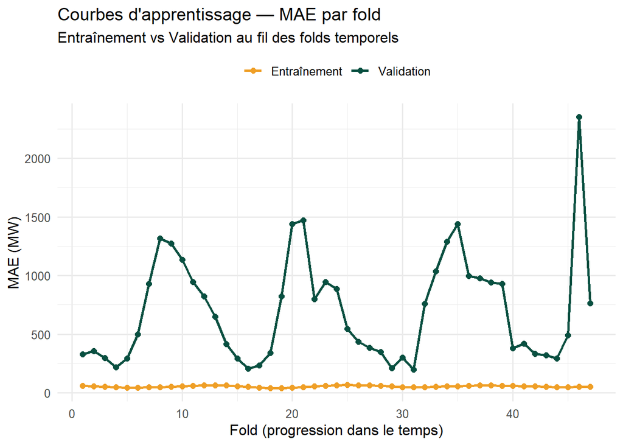

```r
# Extraction des métriques MAE par fold pour la meilleure configuration
courbe_validation <- collect_metrics(resultats_tuning, summarize = FALSE) %>%
  filter(
    .metric == "mae",
    .config == best_params$.config
  ) %>%
  arrange(id) %>%
  mutate(fold_num = row_number())

# Calculer le MAE sur le train fold par fold
mae_train_folds <- map_dbl(cv_splits_rapide$splits, function(split) {
  df_fold_train <- training(split)
  pred_fold <- fit_final %>% augment(df_fold_train)
  mean(abs(pred_fold$demande_energetique - pred_fold$.pred), na.rm = TRUE)
})

# Combiner train et validation
df_courbes <- bind_rows(
  tibble(
    fold       = seq_along(mae_train_folds),
    mae        = mae_train_folds,
    ensemble   = "Entraînement"
  ),
  tibble(
    fold       = courbe_validation$fold_num,
    mae        = courbe_validation$.estimate,
    ensemble   = "Validation"
  )
)

ggplot(df_courbes, aes(x = fold, y = mae, color = ensemble)) +
  geom_line(linewidth = 1) +
  geom_point(size = 2) +
  scale_color_manual(values = c(
    "Entraînement" = "#EF9F27",
    "Validation"   = "#085041"
  )) +
  labs(
    title    = "Courbes d'apprentissage — MAE par fold",
    subtitle = "Entraînement vs Validation au fil des folds temporels",
    x        = "Fold (progression dans le temps)",
    y        = "MAE (MW)",
    color    = NULL
  ) +
  theme_minimal(base_size = 12) +
  theme(legend.position = "top")
```

## Sauvegarde des fichiers pour le dashboard

```r
# Création des dossiers
dir.create("model",            showWarnings = FALSE)
dir.create("data/processed",   recursive = TRUE, showWarnings = FALSE)

# Sauvegarde des données Hydro Québec
write_csv(df,
          "data/processed/energetique.csv")

# Sauvegarde des données météorologiques
write_csv(df_meteo,
          "data/processed/meteo.csv")

# Sauvegarde des données fusionnées
write_csv(df_fusionne, "data/processed/donnee_fusionne.csv")
# Sauvegarde de train et test
write_csv(df_train, "data/processed/train.csv")
write_csv(df_test, "data/processed/test.csv")

# Sauvegarde du modèle XGBoost
saveRDS(fit_final,        "model/xgboost_energie.rds")

# Sauvegarde des résultats de tuning
saveRDS(resultats_tuning, "model/resultats_tuning.rds")

# Sauvegarde des prédictions du jeu de test
predictions %>%
  select(date, demande_energetique, pred_xgb = .pred) %>%
  write_csv("data/processed/predictions_test.csv")

# Vérification des fichiers sauvegardés
cat("Vérification des fichiers :\n")
```

```
## Vérification des fichiers :
```

```r
cat("xgboost_energie.rds    :", file.exists("model/xgboost_energie.rds"), "\n")
```

```
## xgboost_energie.rds    : TRUE
```

```r
cat("resultats_tuning.rds   :", file.exists("model/resultats_tuning.rds"), "\n")
```

```
## resultats_tuning.rds   : TRUE
```

```r
cat("predictions_test.csv   :", file.exists("data/processed/predictions_test.csv"), "\n")
```

```
## predictions_test.csv   : TRUE
```

```r
cat("train.csv          :",
    file.exists("data/processed/train.csv"),  "\n")
```

```
## train.csv          : TRUE
```

```r
cat("test.csv          :",
    file.exists("data/processed/test.csv"),  "\n")
```

```
## test.csv          : TRUE
```

```r
cat("donnee_fusionne.csv          :",
    file.exists("data/processed/donnee_fusionne.csv"),  "\n")
```

```
## donnee_fusionne.csv          : TRUE
```